# Spatial Data Objects: Exercises

## Exercises

These exercises accompany the [Spatial Data Objects](http://rpubs.com/NateByers/spatialobjects) tutorial.

Use the following code to download 2014 daily SO<sub>2</sub> data for the United States. This data will be used in the excercises.

```r
# create a temporary file
temp <- tempfile()

# download the .zip file to a temporary file--this will take several minutes
download.file('http://aqsdr1.epa.gov/aqsweb/aqstmp/airdata/daily_42401_2014.zip', temp)

# unzip temporary file to your working directory
unzip(temp)

# delete the temporary file
unlink(temp)

# read the data into R
so2 <- read.csv('daily_42401_2014.csv', stringsAsFactors = FALSE)
```

1. Use `dplyr` to summarize the `so2` data frame so that each monitor has one record with a column for the SO<sub>2</sub> mean for the entire year.

Solution

2. Use the data frame created in the first exercise to create a `SpatialPoints` object.

Solution

3. Use the data frame and `SpatialPoints` object created in the first two exercises to make a `SpatialPointsDataFrame`.

Solution

4. Plot the `SpatialPointsDataFrame`.

Solution

5. Plot the monitors that are in Region 5 (Illinois, Indiana, Michigan, Minnesota, Ohio, Wisconsin).

Solution

## Solutions

### Solution 1

```r
library(dplyr)
as.tbl(so2)
```

```
## Source: local data frame [324,818 x 29]
##
##    State.Code County.Code Site.Num Parameter.Code   POC Latitude Longitude
##         (int)       (int)    (int)          (int) (int)    (dbl)     (dbl)
## 1           1          73       23          42401     2 33.55306   -86.815
## 2           1          73       23          42401     2 33.55306   -86.815
## 3           1          73       23          42401     2 33.55306   -86.815
## 4           1          73       23          42401     2 33.55306   -86.815
## 5           1          73       23          42401     2 33.55306   -86.815
## 6           1          73       23          42401     2 33.55306   -86.815
## 7           1          73       23          42401     2 33.55306   -86.815
## 8           1          73       23          42401     2 33.55306   -86.815
## 9           1          73       23          42401     2 33.55306   -86.815
## 10          1          73       23          42401     2 33.55306   -86.815
## ..        ...         ...      ...            ...   ...      ...       ...
## Variables not shown: Datum (chr), Parameter.Name (chr), Sample.Duration
##   (chr), Pollutant.Standard (chr), Date.Local (chr), Units.of.Measure
##   (chr), Event.Type (chr), Observation.Count (int), Observation.Percent
##   (dbl), Arithmetic.Mean (dbl), X1st.Max.Value (dbl), X1st.Max.Hour (int),
##   AQI (int), Method.Code (int), Method.Name (chr), Local.Site.Name (chr),
##   Address (chr), State.Name (chr), County.Name (chr), City.Name (chr),
##   CBSA.Name (chr), Date.of.Last.Change (chr)
```

```r
so2_mean <- group_by(so2, State.Code, County.Code, Site.Num,
                    Latitude, Longitude, Datum, State.Name,
                    County.Name, City.Name, CBSA.Name)
so2_mean <- summarize(so2_mean, so2_mean = mean(Arithmetic.Mean, na.rm = TRUE))
as.tbl(so2_mean)
```

```
## Source: local data frame [461 x 11]
## Groups: State.Code, County.Code, Site.Num, Latitude, Longitude, Datum, State.Name, County.Name, City.Name [?]
##
##    State.Code County.Code Site.Num Latitude  Longitude Datum State.Name
##         (int)       (int)    (int)    (dbl)      (dbl) (chr)      (chr)
## 1           1          73       23 33.55306  -86.81500 WGS84    Alabama
## 2           1          73     1003 33.48556  -86.91500 WGS84    Alabama
## 3           1          97        3 30.76994  -88.08753 NAD83    Alabama
## 4           2          90       34 64.84569 -147.72741 NAD83     Alaska
## 5           4           7        9 33.39914 -110.85890 WGS84    Arizona
## 6           4           7       11 33.38550 -110.86727 NAD83    Arizona
## 7           4           7       12 33.39743 -110.87445 NAD83    Arizona
## 8           4           7     1001 33.00618 -110.78580 WGS84    Arizona
## 9           4          12     8000 34.23190 -113.58000 WGS84    Arizona
## 10          4          13     3002 33.45793 -112.04601 WGS84    Arizona
## ..        ...         ...      ...      ...        ...   ...        ...
## Variables not shown: County.Name (chr), City.Name (chr), CBSA.Name (chr),
##   so2_mean (dbl)
```

Back to exercises

### Solution 2

We need to make sure that there is one projection.

```r
unique(so2_mean$Datum)
```

```
## [1] "WGS84"   "NAD83"   "NAD27"   "UNKNOWN"
```

We’ll assume that “UNKNOWN” is actually “WGS84” and make three `SpatialPoints` objects.

```r
library(sp)
so2_wgs84 <- filter(so2_mean, Datum %in% c("WGS84", "UNKNOWN"))
so2_nad83 <- filter(so2_mean, Datum == "NAD83")
so2_nad27 <- filter(so2_mean, Datum == "NAD27")

so2_wgs84_coords <- cbind(so2_wgs84$Longitude, so2_wgs84$Latitude)
row.names(so2_wgs84_coords) <- paste0(so2_wgs84$State.Code, so2_wgs84$County.Code,
                                      so2_wgs84$Site.Num)
so2_nad83_coords <- cbind(so2_nad83$Longitude, so2_nad83$Latitude)
row.names(so2_nad83_coords) <- paste0(so2_nad83$State.Code, so2_nad83$County.Code,
                                      so2_nad83$Site.Num)
so2_nad27_coords <- cbind(so2_nad27$Longitude, so2_nad27$Latitude)
row.names(so2_nad27_coords) <- paste0(so2_nad27$State.Code, so2_nad27$County.Code,
                                      so2_nad27$Site.Num)

wgs84 <- CRS("+proj=longlat +ellpsWGS84")
nad83 <- CRS("+proj=longlat +ellpsNAD83")
nad27 <- CRS("+proj=longlat +ellpsNAD83")

so2_wgs84_spoints <- SpatialPoints(coords = so2_wgs84_coords, proj4string = wgs84)
so2_nad83_spoints <- SpatialPoints(coords = so2_nad83_coords, proj4string = nad83)
so2_nad27_spoints <- SpatialPoints(coords = so2_nad27_coords, proj4string = nad27)
```

Now we transform all of the projections to WGS84 and combine them into one `SpatialPoints` object.

```r
so2_transformed <- spTransform(so2_nad83_spoints, CRSobj = wgs84)
so2_spoints <- rbind(so2_wgs84_spoints, so2_transformed)
so2_transformed <- spTransform(so2_nad27_spoints, CRSobj = wgs84)
so2_spoints <- rbind(so2_spoints, so2_transformed)
```

Back to exercises

### Solution 3

Make sure that the row names for the data frame are the same as the row names for the `SpatialPoints` object. Also, change the class back to `data.frame`.

```r
row.names(so2_mean) <- paste0(so2_mean$State.Code, so2_mean$County.Code,
                              so2_mean$Site.Num)
so2_mean <- as.data.frame(so2_mean)
so2_spdf <- SpatialPointsDataFrame(so2_spoints, so2_mean,
                                  proj4string = wgs84,
                                  match.ID = TRUE)
```

Back to exercises

### Solution 4

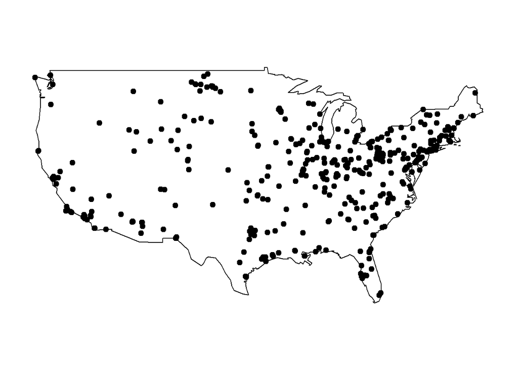

```r
library(maps)
map(database = 'usa')
plot(so2_spdf, pch = 19, add = TRUE)
```

Back to exercises

### Solution 5

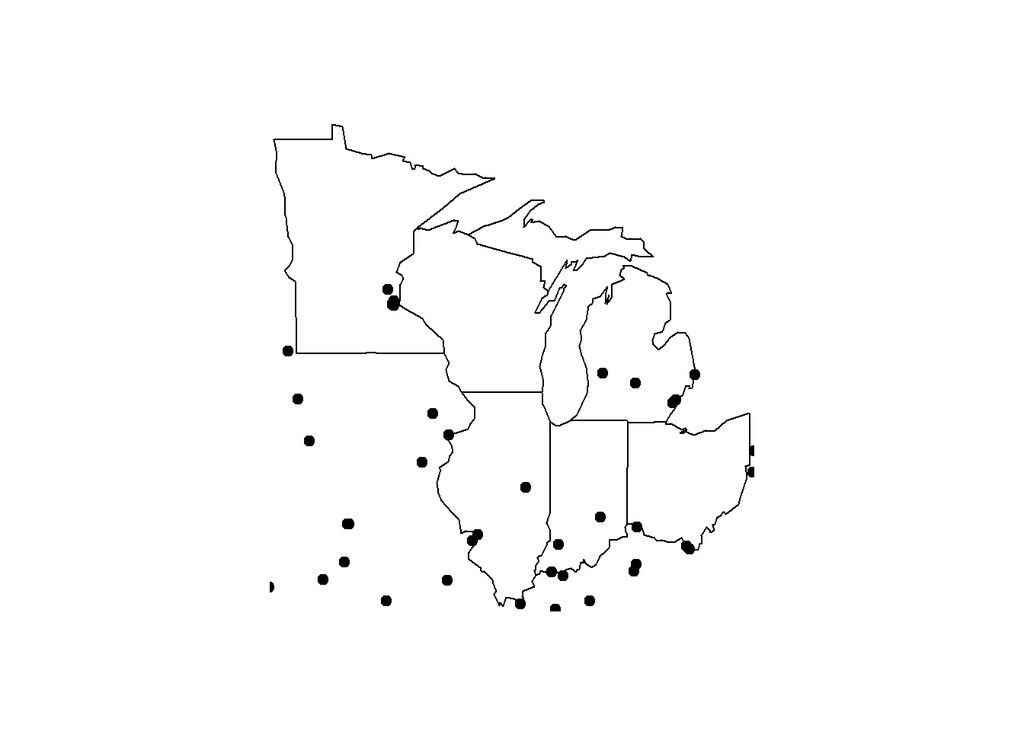

```r
map(database = 'state', regions = c("illinois", "indiana", "michigan",
                                         "minnesota", "ohio", "wisconsin"))
so2_region5_spdf <- so2_spdf[so2_spdf$State.Name %in%
                                     c("Illinois", "Indiana", "Michigan",
                                       "Minnesota", "Ohio", "Wisconsin"), ]
plot(so2_region5_spdf, pch = 19, add = TRUE)
```

Huh. That’s weird.

Back to exercises